# Good Plot / Bad Plot: European Stock Indices, 1991-1998

How the same dataset can lie to you or tell you the truth

Author

Yang An

Published

September 30, 2026

## Introduction

This report uses **`EuStockMarkets`**, a dataset built into base R containing the daily closing prices of four major European stock indices from 1991 to 1998:

- **DAX** (Germany, in Deutsche Marks)
- **SMI** (Switzerland, in Swiss Francs)
- **CAC** (France, in French Francs)
- **FTSE** (United Kingdom, in British Pounds)

The goal of this assignment is to show *the same underlying data* told two very different ways: first as a deliberately **bad, misleading plot**, and then as a **good, honest plot**. Every design choice below is intentional – the bad plot is a checklist of things *not* to do, and the good plot fixes each one.

```r
# Convert the ts object into a tidy long-format data frame.
# time() gives decimal years (e.g. 1991.496); date_decimal() turns that
# into a real Date so we can filter and format it normally.
eu_stocks <- as.data.frame(EuStockMarkets) |>
  mutate(date = date_decimal(as.numeric(time(EuStockMarkets))) |> as.Date()) |>
  pivot_longer(cols = c(DAX, SMI, CAC, FTSE),
               names_to = "market_index",
               values_to = "closing_level") |>
  arrange(market_index, date)

glimpse(eu_stocks)
```

```
Rows: 7,440
Columns: 3
$ date          <date> 1991-07-01, 1991-07-02, 1991-07-03, 1991-07-05, 1991-07~
$ market_index  <chr> "CAC", "CAC", "CAC", "CAC", "CAC", "CAC", "CAC", "CAC", ~
$ closing_level <dbl> 1772.8, 1750.5, 1718.0, 1708.1, 1723.1, 1714.3, 1734.5, ~
```

## The Bad Plot

**Important**

**Don’t do this.** The plot below answers a real (bad) question a beginner might ask: *“which market is bigger?”* – by just plotting the raw closing values on top of each other and drawing a dramatic conclusion.

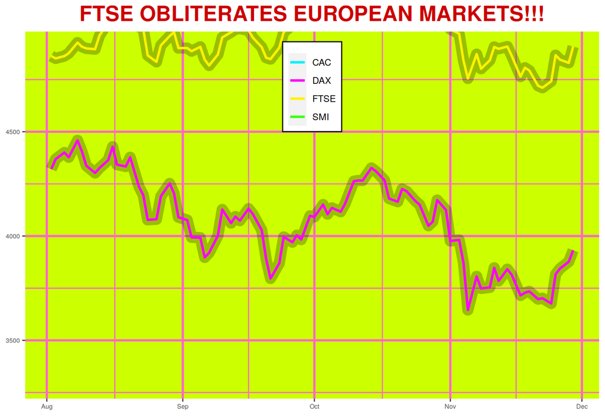

Figure 1: BAD: raw index levels plotted on a truncated axis, over a cherry-picked window, in clashing colors, with a misleading headline.

```r
# Cherry-pick a short, dramatic-looking window instead of the full
# 1991-1998 history (hides the bigger, more representative picture).
bad_data <- eu_stocks |>
  filter(date >= as.Date("1997-08-01"), date <= as.Date("1997-11-30"))

ggplot(bad_data, aes(x = date, y = closing_level, color = market_index)) +
  # Fake "3D drop shadow" chart-junk: a thick, blurry duplicate line
  # underneath that adds visual noise but zero information.
  geom_line(aes(group = market_index), color = "black", alpha = 0.25,
            linewidth = 5) +
  geom_line(linewidth = 1.1) +
  # Clashing, non-colorblind-safe neon palette.
  scale_color_manual(values = c(
    DAX = "#FF00FF", SMI = "#39FF14", CAC = "#00F0FF", FTSE = "#FFF200"
  )) +
  # Truncated y-axis: starts near the data minimum instead of zero,
  # which exaggerates how far apart the four lines look.
  coord_cartesian(ylim = c(3300, 4900)) +
  labs(
    # All-caps, editorializing, unsupported headline.
    title = "FTSE OBLITERATES EUROPEAN MARKETS!!!",
    x = NULL, y = NULL, color = NULL   # no axis labels, no units
  ) +
  theme(
    # Garish background + heavy neon gridlines: pure chart-junk.
    panel.background = element_rect(fill = "#CCFF00"),
    panel.grid.major = element_line(color = "#FF66CC", linewidth = 1),
    panel.grid.minor = element_line(color = "#FF66CC", linewidth = 0.5),
    plot.title = element_text(size = 20, face = "bold", color = "#CC0000",
                               hjust = 0.5),
    # Tiny, hard-to-read axis text.
    axis.text = element_text(size = 6),
    # Legend plopped on top of the data instead of beside it.
    legend.position = c(0.5, 0.85),
    legend.background = element_rect(fill = "white", color = "black")
  )
```

### Every principle this plot breaks

1. **Truncated y-axis that deletes data, not just distorts it.** The axis is fixed to 3300-4900. Over this exact window, CAC actually ranges from 2651-3094 and SMI from 5217-5930 – both *entirely outside* those limits. That’s why the legend lists four indices but only two lines (DAX and FTSE) are visible: CAC and SMI aren’t small or hidden behind another line, they’ve been clipped out of the plot completely by the axis choice.
2. **Apples-to-oranges units.** DAX, SMI, CAC, and FTSE are in four *different currencies* with four different bases. Plotting their raw levels together and declaring a “winner” is meaningless – FTSE only looks biggest because British pounds and the FTSE’s index base happen to produce larger numbers, not because the UK market performed better.
3. **Cherry-picked time window.** Only four months (Aug-Nov 1997) are shown, hand-picked because the lines happen to separate dramatically, instead of the full 1991-1998 history.
4. **Misleading, unsupported title.** “FTSE OBLITERATES EUROPEAN MARKETS” is an editorial claim the data doesn’t actually support once you account for (1) and (2).
5. **Non-colorblind-safe, clashing color palette.** Neon magenta, green, cyan, and yellow are hard to tell apart and inaccessible to colorblind viewers.
6. **No axis labels or units.** A reader has no idea whether they’re looking at points, dollars, or percent.
7. **Chart-junk.** The blurry “drop shadow” duplicate lines and the neon background/gridlines add visual noise without adding information – they actively distract from the data.
8. **Illegible tiny axis text** paired with a legend dropped **on top of the data** instead of beside it, actively blocking part of the plot.
9. **No data source cited**, so none of this could even be checked.

## The Good Plot

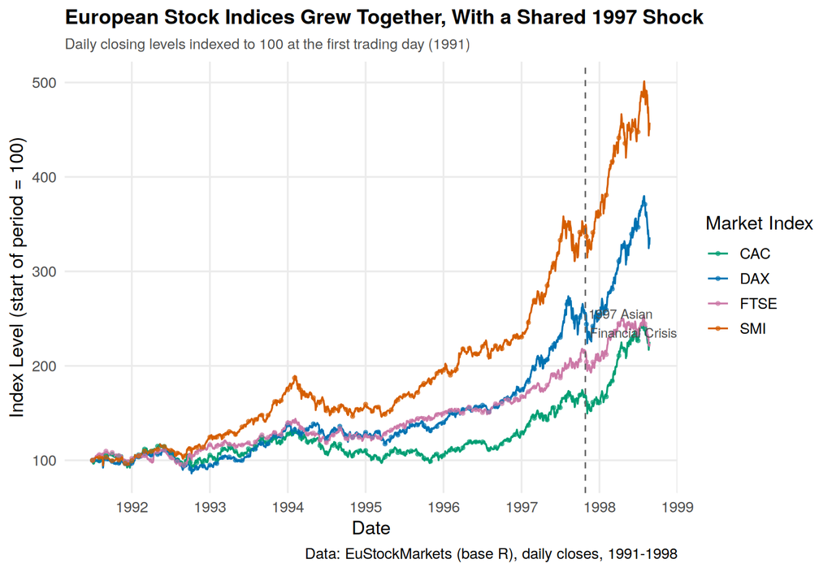

Figure 2: GOOD: all four indices normalized to a common base (=100 at the start), full 1991-1998 history, colorblind-safe palette, clearly labeled.

```r
# Fix problem #2 first: normalize every index to 100 at its first
# observation. This converts four incompatible currencies into one
# comparable unit -- "percent of starting value" -- so the lines can
# honestly be compared.
good_data <- eu_stocks |>
  group_by(market_index) |>
  mutate(indexed_level = closing_level / first(closing_level) * 100) |>
  ungroup()

# A handful of raw monthly observations, drawn as points on top of the
# line, so the underlying raw data points are visible, not just a
# smoothed summary.
monthly_points <- good_data |>
  mutate(year_month = floor_date(date, "month")) |>
  group_by(market_index, year_month) |>
  slice(1) |>
  ungroup()

ggplot(good_data, aes(x = date, y = indexed_level, color = market_index)) +
  # Full 1991-1998 history -- no cherry-picking.
  geom_line(linewidth = 0.6) +
  geom_point(data = monthly_points, size = 1, alpha = 0.6) +
  # Mark the 1997 Asian Financial Crisis, the real story in this period.
  geom_vline(xintercept = as.Date("1997-10-27"), linetype = "dashed",
             color = "grey40", linewidth = 0.5) +
  annotate("text", x = as.Date("1997-10-27"), y = 245,
           label = "1997 Asian\nFinancial Crisis", hjust = -0.05,
           size = 3.2, color = "grey30") +
  # Colorblind-safe Okabe-Ito palette, used consistently all course.
  scale_color_manual(values = c(
    DAX = "#0072B2", SMI = "#D55E00", CAC = "#009E73", FTSE = "#CC79A7"
  )) +
  scale_x_date(date_breaks = "1 year", date_labels = "%Y") +
  labs(
    title = "European Stock Indices Grew Together, With a Shared 1997 Shock",
    subtitle = "Daily closing levels indexed to 100 at the first trading day (1991)",
    x = "Date",
    y = "Index Level (start of period = 100)",
    color = "Market Index",
    caption = "Data: EuStockMarkets (base R), daily closes, 1991-1998"
  ) +
  theme_minimal(base_size = 13) +
  theme(
    plot.title = element_text(face = "bold", size = 14),
    plot.subtitle = element_text(size = 10, color = "grey30"),
    legend.position = "right",
    panel.grid.minor = element_blank()
  )
```

### Why this version works

- **Same base, fair comparison.** Every index starts at 100, so a reader can directly compare *growth rates* across four different currencies – something the bad plot never made possible.
- **The full time series is shown**, not a cherry-picked slice, so the 1997 dip is visible in context as a shared shock across *all four* markets rather than a dramatic isolated event.
- **Colorblind-safe palette** (Okabe-Ito) keeps all four lines distinguishable for every reader.
- **Clear labels, units, and a caption** mean the plot can stand on its own without the surrounding text.
- **The legend sits beside the plot**, never covering data, and the underlying raw daily closes are still what’s plotted (with monthly points layered on top) – nothing here is smoothed or hidden.

## Conclusion

Both plots come from *exactly the same* underlying dataset. The only difference is a handful of design decisions – whether the y-axis is truncated, whether the data is cherry-picked, whether units are made comparable, and whether the color palette and labeling respect the reader. Those decisions are the entire difference between a chart that misleads and a chart that informs.